# Practical Machine Learning - Human Activity Recognition

Paulo Faleiros

January 19, 2019

## Overview

The objective of this project is to generate a model to predict the manner a certain individual performs a weight lift exercise. The exercise can be done correctly (class A) or with 4 different types of flaws (classes B, C, D and E). Based on data collected by sensors in athletes’ arms, foreams, belts and in the dumbell, the model, after been trained, needs to be able to predict the exercise class for 20 test cases.

## Data Preparation

Read data

```r
setwd("C:/Users/paulo.faleiros/Google Drive/Coursera/courses/JHU-DS/code")
trainingRdat = read.csv("../data/pml-training.csv", stringsAsFactors = FALSE)
validation = read.csv("../data/pml-testing.csv", stringsAsFactors = FALSE)
```

separate train, test and validation datasets

```r
pmlData = createDataPartition(y=trainingRdat$classe, p=0.7, list=FALSE)
training = trainingRdat[pmlData,]
testing = trainingRdat[-pmlData,]
```

Produce tidy datasets - eliminate noise by removing exercise metadata and variables whose number of valid observations is less than 95% of the dataset. Apply same cleansing criteria to testing and validation datasets.

```r
training[training=="" || training==" " || training=="NA" || training=="#DIV/0!"]<-NA
testing[testing=="" || testing==" " || testing=="NA" || testing=="#DIV/0!"]<-NA

a<-sapply(training[,c(8:159)], function(x) sum(is.na(as.numeric(x))))
predVars<-names(a[((dim(training)[1]-a)/dim(training)[1] > .95)])
newTraining <- training[,predVars]
newTraining$classe <- as.factor(training$classe)

newTesting <- testing[,predVars]
newTesting$classe <- as.factor(testing$classe)

newValidation <- validation[,predVars]
```

## Model creation

In this section, some classification models will be evaluated and the best will be selected to conduct the exercise class prediction.

#### CART model

First try will be done with a simple Classification And Regression Trees (CART) model. Train a CART model with all predictors and generate a prediction with the testing set.

```r
system.time({ fit.rpart <- train(classe ~ ., data=newTraining, method="rpart") })
```

```
##    user  system elapsed
##   13.75    0.52   14.36
```

```r
c<-confusionMatrix(newTesting$classe, predict(fit.rpart, newTesting))
kable(c$table) %>% kable_styling(bootstrap_options = "striped", full_width = F)
```

|  | A | B | C | D | E |
| --- | --- | --- | --- | --- | --- |
| A | 1514 | 21 | 138 | 0 | 1 |
| B | 487 | 370 | 282 | 0 | 0 |
| C | 451 | 38 | 537 | 0 | 0 |
| D | 444 | 165 | 355 | 0 | 0 |
| E | 164 | 148 | 292 | 0 | 478 |

#### Stochastic Gradient Boost model

Previous try demonstrated the data is too complex to generate a simple decision tree model, hence it demands more complex techniques to choose the model. Next try will use a boosting model with cross validation, to improve accuracy.

Train a Stochastic Gradient boosting model and generate a prediction with the testing set. Cross validation is applied with 5 k-folds.

```r
tc <- trainControl(method = 'cv', number = 5, summaryFunction=defaultSummary)
system.time({ fit.gbm <- train(classe ~ ., data=newTraining, method="gbm",
                               trControl=tc, verbose=FALSE) })
```

```
##    user  system elapsed
##  290.27    1.03  296.97
```

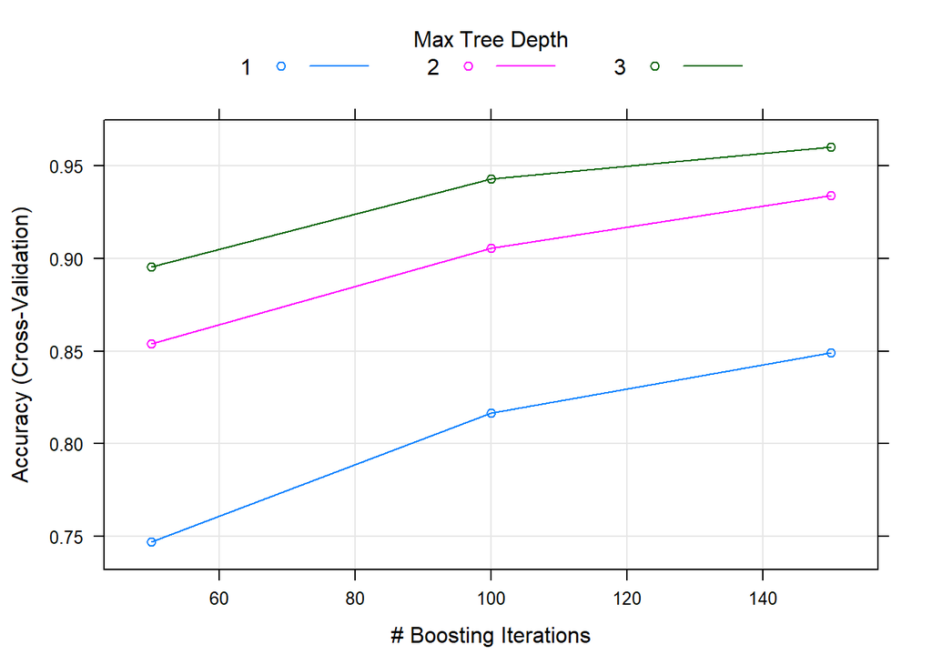

```r
plot(fit.gbm)
```

The chart demonstrates accuracy hits its peak with 3 Max Tree Depth and 150 boosting interactions:

```r
kable(fit.gbm$results) %>% kable_styling("striped", full_width = F) %>% row_spec(which(fit.gbm$results$interaction.depth ==
                                fit.gbm$bestTune$interaction.depth
                            & fit.gbm$results$n.trees ==
                                fit.gbm$bestTune$n.trees), bold = T, color = "silver", background = "navy")
```

|  | shrinkage | interaction.depth | n.minobsinnode | n.trees | Accuracy | Kappa | AccuracySD | KappaSD |
| --- | --- | --- | --- | --- | --- | --- | --- | --- |
| 1 | 0.1 | 1 | 10 | 50 | 0.7468143 | 0.6790460 | 0.0043105 | 0.0055526 |
| 4 | 0.1 | 2 | 10 | 50 | 0.8540415 | 0.8151307 | 0.0100754 | 0.0128033 |
| 7 | 0.1 | 3 | 10 | 50 | 0.8955365 | 0.8677673 | 0.0074600 | 0.0094750 |
| 2 | 0.1 | 1 | 10 | 100 | 0.8164069 | 0.7676582 | 0.0067423 | 0.0085308 |
| 5 | 0.1 | 2 | 10 | 100 | 0.9057283 | 0.8807195 | 0.0069606 | 0.0087849 |
| 8 | 0.1 | 3 | 10 | 100 | 0.9429268 | 0.9277775 | 0.0060774 | 0.0076840 |
| 3 | 0.1 | 1 | 10 | 150 | 0.8491654 | 0.8091770 | 0.0060243 | 0.0076038 |
| 6 | 0.1 | 2 | 10 | 150 | 0.9340453 | 0.9165305 | 0.0069689 | 0.0088178 |
| 9 | 0.1 | 3 | 10 | 150 | 0.9601071 | 0.9495328 | 0.0047421 | 0.0059885 |

```r
c<-confusionMatrix(newTesting$classe, predict(fit.gbm, newTesting))
kable(c$table) %>% kable_styling(bootstrap_options = "striped", full_width = F)
```

|  | A | B | C | D | E |
| --- | --- | --- | --- | --- | --- |
| A | 1649 | 20 | 3 | 2 | 0 |
| B | 39 | 1078 | 21 | 0 | 1 |
| C | 0 | 26 | 987 | 12 | 1 |
| D | 0 | 4 | 41 | 909 | 10 |
| E | 2 | 15 | 8 | 10 | 1047 |

Model considerations:

## Validation dataset

```r
predictions<-predict(fit.gbm, validation)
print(as.character(predictions))
```

```
##  [1] "B" "A" "B" "A" "A" "E" "D" "B" "A" "A" "B" "C" "B" "A" "E" "E" "A"
## [18] "B" "B" "B"
```

## Conclusion

The Stochastic Gradient Boost model choice produced a fairly more accurate model, but the processing time to train it may raise a scalability issue. The model can be tuned by simplifying the predictors, and the Variables Importance analysis demonstrates it:

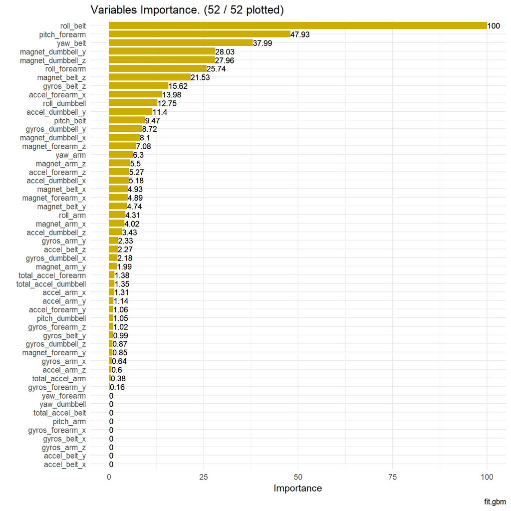

Variables Importance for fit.gbm model

An equivalent model could be trained with 36 predictors instead of 52, which would reduce the model complexity and allow better scalability.